# Multitrait BLUP with metan

Maarit Mäenpää

2025-02-03

A case of a single experiment: One environment, multiple genotypes.

### Packages needed in the example

```r
library(agridat) # for dataset
library(dplyr)
library(metan)
library(ggplot2)
```

# Prepare an example dataset

Using barrero.maize from agridat. This is a multi-year, multi-trait, multi-environment dataset, where for the sake of an example, we extract one year and one location. We omit all missing values.

```r
# Load in the data
data(barrero.maize)
head(barrero.maize)
```

```
##   year  yor loc    env rep  gen daystoflower plantheight earheight population
## 1 2000 2000  BA 2000BA  R1 9211           78      233.68     83.82   57407.43
## 2 2000 2000  BA 2000BA  R2 9211           77      236.22     76.20   61712.00
## 3 2000 2000  BA 2000BA  R3 9211           77      228.60     78.74   57407.43
## 4 2000 2000  BA 2000BA  R4 9211           78      241.30     88.90   60278.79
## 5 2000 2000  BA 2000BA  R1 9114           77      243.84     88.90   59559.72
## 6 2000 2000  BA 2000BA  R2 9114           78      236.22     78.74   58124.04
##   lodged moisture testweight    yield
## 1      0     11.2   81.40275 9.791345
## 2      0     10.7   81.41562 9.481665
## 3      0     10.7   80.38602 8.690092
## 4      0     11.3   83.10159 9.247033
## 5      0     10.1         NA 7.968912
## 6      0     10.3   79.00893 9.361655
```

```r
# For details of the data
#?barrero.maize

# Select one location in one year
maize.BA <- filter(barrero.maize, loc=="BA" & year=="2000")

# Omit all NA's
maize.BA <- na.omit(maize.BA)

# Make sure genotypes that are removed due to missing data are not stored as a level in the genotype by reassigning the factor
maize.BA$gen <- factor(maize.BA$gen)
```

# Run a model with metan

Need to specify the dataset (maize.BA), the column identifying the genotype (gen), replication (rep), and the response variables of interest. Here, there are 8 traits measured.

```r
mod <-
  gamem(maize.BA,
        gen=gen,
        rep=rep,
        resp=c(daystoflower, plantheight, earheight, population, lodged, moisture, testweight, yield))
```

[output not shown]

```
## ---------------------------------------------------------------------------
## P-values for Likelihood Ratio Test of the analyzed traits
## ---------------------------------------------------------------------------
##     model daystoflower plantheight earheight population lodged moisture
##  Complete           NA          NA        NA         NA     NA       NA
##  Genotype     2.46e-27    4.24e-29  1.67e-15    0.00945 0.0638 3.03e-14
##  testweight    yield
##          NA       NA
##    0.000104 4.72e-10
## ---------------------------------------------------------------------------
## Variables with nonsignificant Genotype effect
## lodged
## ---------------------------------------------------------------------------
```

Note that the output after running the model indicates a brief overview of which traits differ between genotypes. In this case only the trait “lodged” did not differentiate between different genotypes.

# BLUPs

Plot the individual BLUPs (best linear unbiased predictors) from the model.

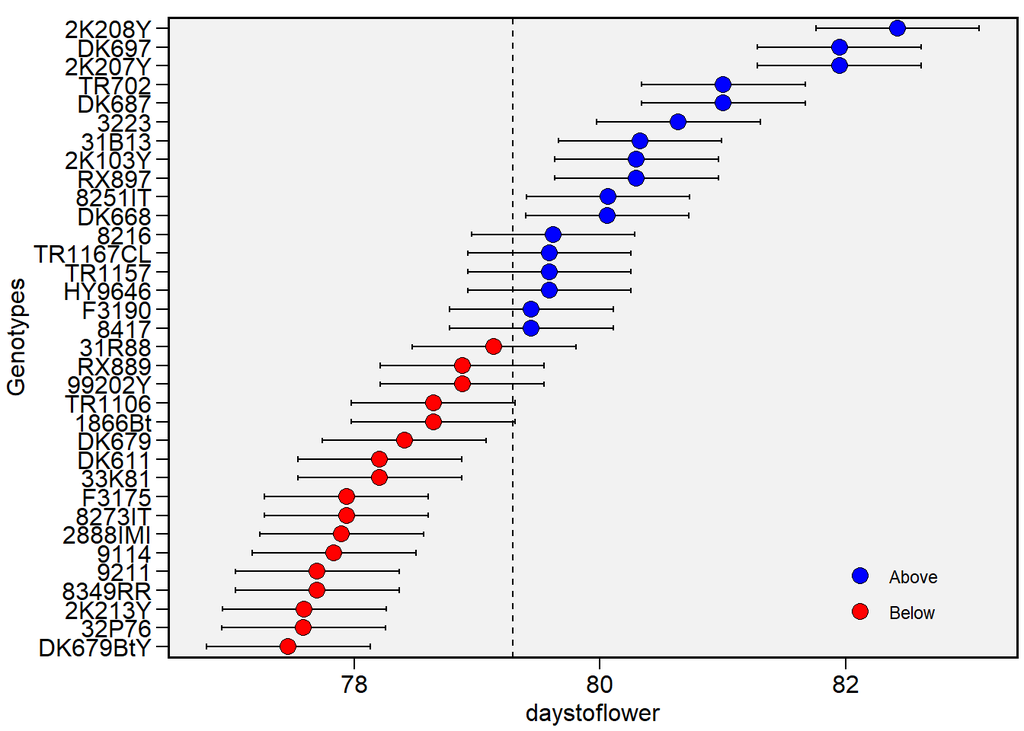

```r
plot_blup(mod, var = "daystoflower")
```

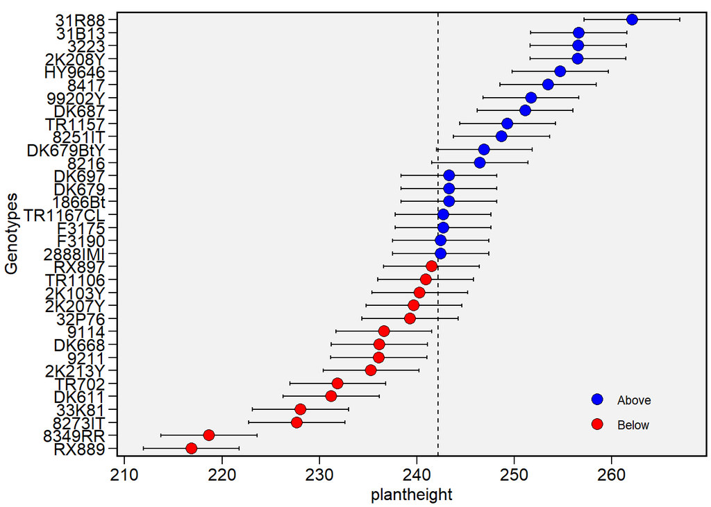

```r
plot_blup(mod, var = "plantheight")
```

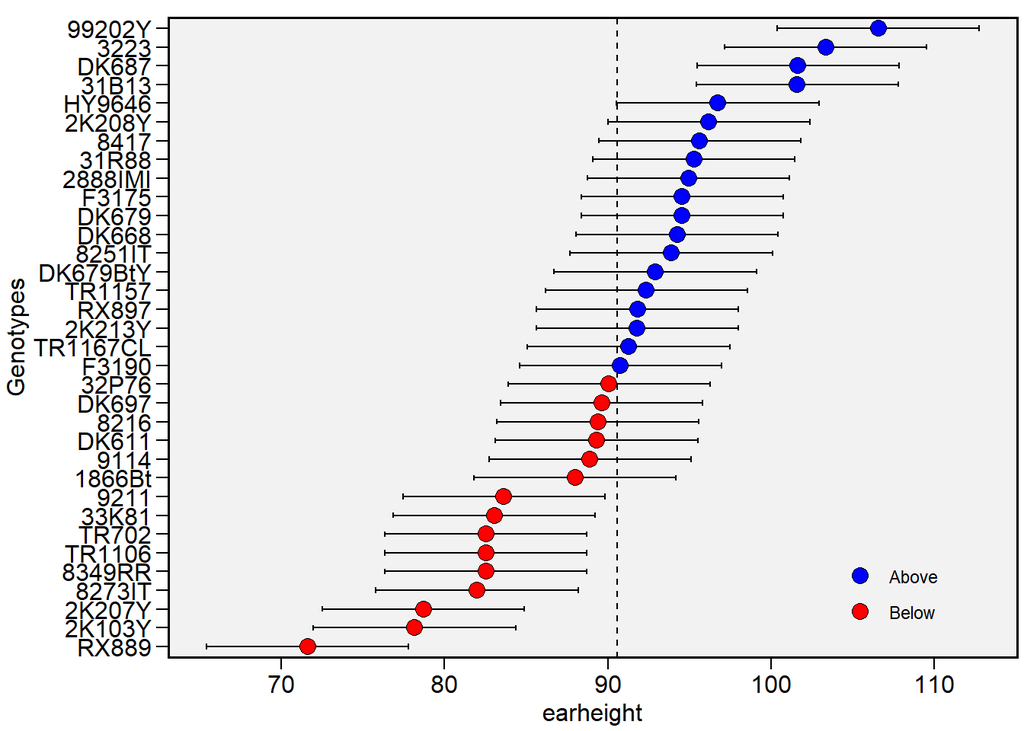

```r
plot_blup(mod, var = "earheight")
```

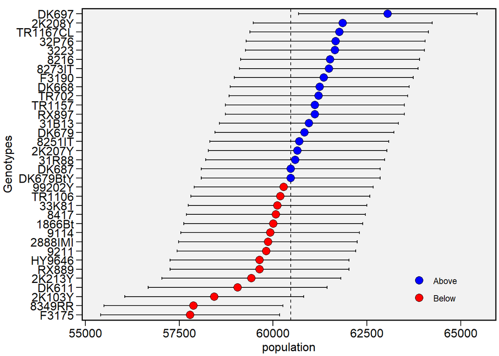

```r
plot_blup(mod, var = "population")
```

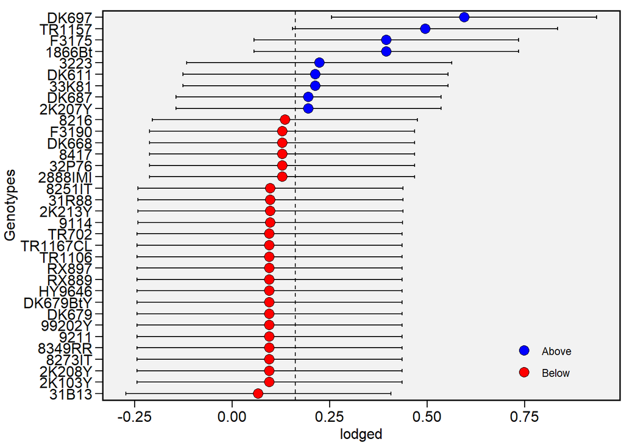

```r
plot_blup(mod, var = "lodged")
```

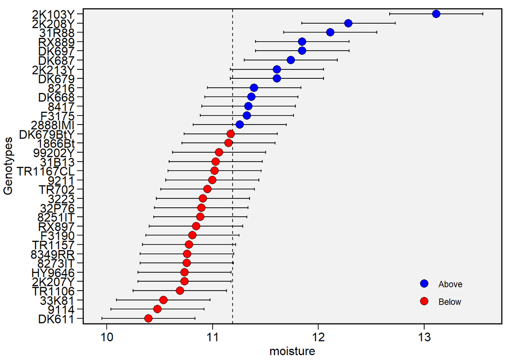

```r
plot_blup(mod, var = "moisture")
```

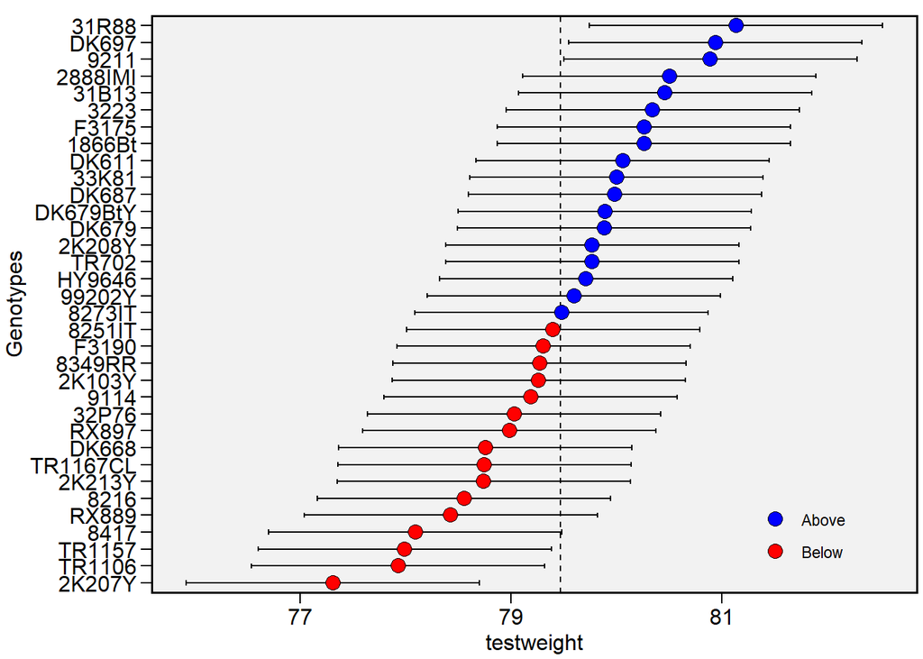

```r
plot_blup(mod, var = "testweight")
```

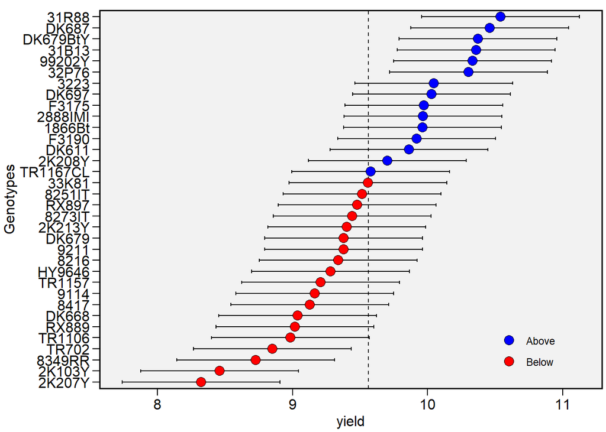

```r
plot_blup(mod, var = "yield")
```

# Assess the model

### Broad sense heritability

Proportion of phenotypic variance due to genetic factors.

```r
get_model_data(mod, "h2") # broad-sense heritability
```

```
## Class of the model: gamem
```

```
## Variable extracted: h2
```

```
##            VAR        h2
## 1 daystoflower 0.9439548
## 2  plantheight 0.9466682
## 3    earheight 0.8597853
## 4   population 0.5155175
## 5       lodged 0.3992717
## 6     moisture 0.8723022
## 7   testweight 0.6563036
## 8        yield 0.8015240
```

### Model details

**Ngen** - The number of genetic entries or genotypes evaluated.

**OVmean** - The overall mean value for each trait across all genotypes.

**Min** - The minimum observed value for each trait, with the genotype and replication noted.

**Max** - The maximum observed value for each trait, with the genotype and replication noted.

**MinGEN** - The minimum genetic value for each trait, indicating the lowest value among the genotypes.

**MaxGEN** - The maximum genetic value for each trait, indicating the highest value among the genotypes.

```r
get_model_data(mod, "details") # General details
```

```
## Class of the model: gamem
```

```
## Variable extracted: details
```

```
## # A tibble: 6 × 9
##   Parameters daystoflower      plantheight  earheight population lodged moisture
##   <chr>      <chr>             <chr>        <chr>     <chr>      <chr>  <chr>
## 1 Ngen       34                34           34        34         34     34
## 2 OVmean     79.2923           242.1988     90.5998   60465.5671 0.1615 11.1893
## 3 Min        76 (32P76 in R1)  210.82 (834… 63.5 (RX… 48079.219… 0 (92… 10.1 (9…
## 4 Max        83 (2K208Y in R2) 269.24 (31B… 114.3 (9… 68887.931… 3 (TR… 13.7 (2…
## 5 MinGEN     77.25 (DK679BtY)  214.63 (RX8… 67.945 (… 55254.531… 0 (28… 10.2333…
## 6 MaxGEN     82.5 (2K208Y)     262.4667 (3… 108.585 … 65480.971… 1.25 … 13.4 (2…
## # ℹ 2 more variables: testweight <chr>, yield <chr>
```

### Likelihood ratio tests

These tests give the p-values (remember, p-values are not everything!) for whether the traits assessed show differences in the genotypes.

```r
get_model_data(mod, "lrt") # P-values for genotype differences within traits
```

```
## Class of the model: gamem
```

```
## Variable extracted: lrt
```

```
## # A tibble: 8 × 8
##   VAR          model     npar logLik   AIC    LRT    Df `Pr(>Chisq)`
##   <chr>        <chr>    <dbl>  <dbl> <dbl>  <dbl> <dbl>        <dbl>
## 1 daystoflower Genotype     5  -244.  499. 117.       1     2.46e-27
## 2 plantheight  Genotype     5  -501. 1013. 125.       1     4.24e-29
## 3 earheight    Genotype     5  -488.  986.  63.4      1     1.67e-15
## 4 population   Genotype     5 -1215. 2440.   6.74     1     9.45e- 3
## 5 lodged       Genotype     5  -107.  223.   3.44     1     6.38e- 2
## 6 moisture     Genotype     5  -153.  316.  57.7      1     3.03e-14
## 7 testweight   Genotype     5  -274.  559.  15.1      1     1.04e- 4
## 8 yield        Genotype     5  -176.  362.  38.8      1     4.72e-10
```

### Genetic parameters

**Gen_var** - Genetic variance, indicating the variability in traits due to genetic differences.

**Gen (%)** - Percentage of total variance attributed to genetic factors.

**Res_var** - Residual variance, representing the variability not explained by genetic or block effects.

**Res (%)** - Percentage of total variance attributed to residual factors.

**Phen_var** - Phenotypic variance, the total observed variability in the traits.

**H2** - Broad-sense heritability, indicating the proportion of phenotypic variance due to genetic factors.

**Accuracy** - The accuracy of the heritability estimates.

**CVg** - Coefficient of genetic variation, a measure of genetic diversity relative to the mean.

**CVr** - Coefficient of residual variation, indicating the residual variability relative to the mean.

**CV ratio** - Ratio of genetic to residual variation, providing insight into the relative contributions of genetic and residual factors

```r
get_model_data(mod, "genpar") # Genetic parameters
```

```
## Class of the model: gamem
```

```
## Variable extracted: genpar
```

```
## # A tibble: 11 × 9
##    Parameters daystoflower plantheight earheight   population   lodged moisture
##    <chr>             <dbl>       <dbl>     <dbl>        <dbl>    <dbl>    <dbl>
##  1 Gen_var           2.02      116.       68.2    2614067.      0.0406    0.381
##  2 Gen (%)          80.8        81.6      60.5         21.0    14.2      63.1
##  3 Res_var           0.480      26.2      44.5    9826783.      0.244     0.223
##  4 Res (%)          19.2        18.4      39.5         79.0    85.8      36.9
##  5 Phen_var          2.50      143.      113.    12440850.      0.285     0.605
##  6 H2                0.808       0.816     0.605        0.210   0.142     0.631
##  7 h2mg              0.944       0.947     0.860        0.516   0.399     0.872
##  8 Accuracy          0.972       0.973     0.927        0.718   0.632     0.934
##  9 CVg               1.79        4.45      9.11         2.67  125.        5.52
## 10 CVr               0.873       2.11      7.36         5.18  306.        4.22
## 11 CV ratio          2.05        2.11      1.24         0.516   0.408     1.31
## # ℹ 2 more variables: testweight <dbl>, yield <dbl>
```

### BLUPs

I.e. predicted means (=point estimates for genotype mean in each trait)

```r
get_model_data(mod, "blupg") # Predicted means
```

```
## Class of the model: gamem
```

```
## Variable extracted: blupg
```

```
## # A tibble: 34 × 9
##    GEN     daystoflower plantheight earheight population lodged moisture
##    <chr>          <dbl>       <dbl>     <dbl>      <dbl>  <dbl>    <dbl>
##  1 1866Bt          78.6        243.      88.0     60006. 0.395      11.1
##  2 2888IMI         77.9        242.      94.9     59863. 0.128      11.3
##  3 2K103Y          80.3        240.      78.2     58434. 0.0955     13.1
##  4 2K207Y          81.9        240.      78.7     60653. 0.195      10.7
##  5 2K208Y          82.4        257.      96.2     61856. 0.0955     12.3
##  6 2K213Y          77.6        235.      91.8     59421. 0.0980     11.6
##  7 31B13           80.3        257.     102.      60958. 0.0672     11.0
##  8 31R88           79.1        262.      95.3     60589. 0.0980     12.1
##  9 3223            80.6        257.     103.      61650. 0.223      10.9
## 10 32P76           77.6        239.      90.1     61668. 0.128      10.9
## # ℹ 24 more rows
## # ℹ 2 more variables: testweight <dbl>, yield <dbl>
```

# FAI-index

Multitrait comparison. The method is documented first here: https://doi.org/10.1111/gcbb.12443

```r
FAI <- fai_blup(mod)
```

```
##
## -----------------------------------------------------------------------------------
## Principal Component Analysis
## -----------------------------------------------------------------------------------
##     eigen.values cumulative.var
## PC1         2.85          35.59
## PC2         1.64          56.13
## PC3         1.11          70.01
## PC4         1.05          83.11
## PC5         0.67          91.43
## PC6         0.38          96.23
## PC7         0.17          98.36
## PC8         0.13         100.00
##
## -----------------------------------------------------------------------------------
## Factor Analysis
## -----------------------------------------------------------------------------------
##                FA1   FA2   FA3   FA4 comunalits
## daystoflower  0.08  0.83 -0.38 -0.10       0.85
## plantheight  -0.69  0.52 -0.20  0.17       0.82
## earheight    -0.86  0.29  0.07  0.16       0.85
## population   -0.18  0.78  0.18 -0.15       0.70
## lodged       -0.05  0.18  0.01 -0.91       0.87
## moisture     -0.04  0.07 -0.96  0.01       0.92
## testweight   -0.69 -0.31 -0.26 -0.35       0.77
## yield        -0.91 -0.03  0.07 -0.19       0.86
##
## -----------------------------------------------------------------------------------
## Comunalit Mean: 0.8310696
## Selection differential
## -----------------------------------------------------------------------------------
## # A tibble: 8 × 9
##   VAR          Factor        Xo        Xs      SD SDperc    h2       SG SGperc
##   <chr>         <dbl>     <dbl>     <dbl>   <dbl>  <dbl> <dbl>    <dbl>  <dbl>
## 1 plantheight       1   242.      251.      9.07    3.75 0.947   8.59    3.55
## 2 earheight         1    90.6      94.2     3.55    3.92 0.860   3.06    3.37
## 3 testweight        1    79.5      80.4     0.950   1.20 0.656   0.624   0.785
## 4 yield             1     9.56     10.1     0.578   6.04 0.802   0.463   4.84
## 5 daystoflower      2    79.3      80.6     1.34    1.69 0.944   1.26    1.59
## 6 population        2 60466.    61195.    730.      1.21 0.516 376.      0.622
## 7 moisture          3    11.2      11.8     0.637   5.69 0.872   0.556   4.97
## 8 lodged            4     0.162     0.276   0.114  70.7  0.399   0.0456 28.2
##
## -----------------------------------------------------------------------------------
## Selected genotypes
## DK697 2K208Y DK687 31R88 1866Bt
## -----------------------------------------------------------------------------------
```

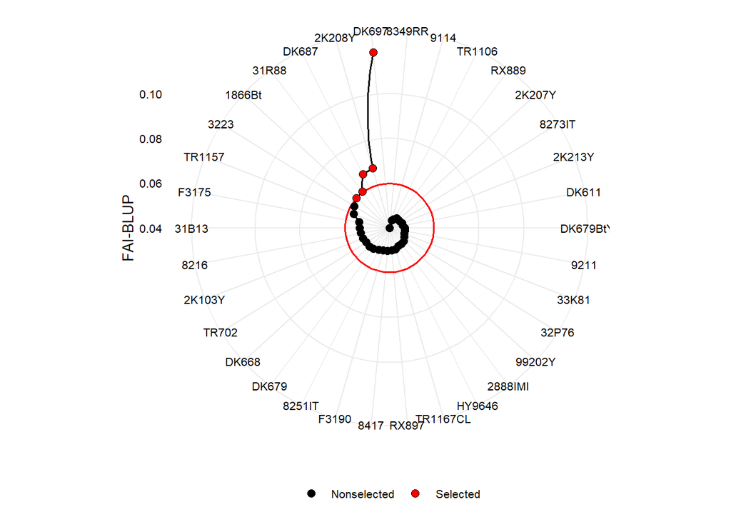

```r
plot(FAI)
```

## FAI ranking and illustrating selected genotypes

Here, genotype selection is not purely for the optimal top performing genotypes, but for diversifying the best- and worst performing genotypes. In this case, we take the top and bottom 2 genotypes, and randomly choose 4 from the middle.

```r
# Save BLUP data for individual traits
metan_blups <- data.frame(get_model_data(mod, "ranef")$GEN)
```

```
## Class of the model: gamem
```

```
## Variable extracted: ranef
```

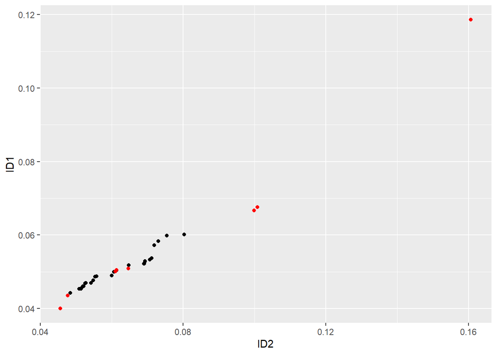

```r
# Extract FAI indexes
FAI_results <- FAI$FAI

# Change the name of Genotype to combine the two dataframes
names(metan_blups)[1] <- "Genotype"

# Combine dataframes
FAI_results <- left_join(FAI_results, metan_blups, by="Genotype")

# Create a dataframe to select genotypes
selected <- data.frame(matrix(NA, nrow = 0, ncol = 25))
colnames(selected) <- colnames(FAI_results)

# Top and bottom 5
selected <- rbind(selected,
                  FAI_results[which(FAI_results$ID1 %in% tail(sort(FAI_results$ID1),2)==T),]
)
selected <- rbind(selected,
                  FAI_results[which(FAI_results$ID1 %in% head(sort(FAI_results$ID1),2)==T),]
)

# Random selection from the middle
rselect <- sample(FAI_results[which(FAI_results$Genotype %in% selected$Genotype==FALSE),]$Genotype, size = 4, replace = F)
selected <- rbind(selected, FAI_results[which(FAI_results$Genotype %in% rselect ==T),])

# Illustrate selection
ggplot(FAI_results, aes(x=ID2, y=ID1)) +
  geom_point() +
  geom_point(data=selected, colour="red")
```

The figure above illustrates the ranked order of the genotypes. The red are selected, and black are not. Distance in ID1 and ID2 illustrate difference between the genotypes.